# Testen der Gleichheit von räumlichen ACF: Eine erste Implementierung

Carsten Stahl

2025-03-17

# Einführung

Dieses Dokument baut auf dem Teststatistik aus Jentsch and Pauly (2015), welche auf die Gleichheit von zwei (oder mehr) Spektraldichten (und somit auch ACFs) testet, auf:
$$\begin{align*}
H_0&: f_X(\omega) = f_Y(\omega) \\
H_1&: \exists \omega_1,\omega_2 | \omega_1< \omega_2: f_X(\omega)
\neq f_Y(\omega) \hspace{1em} \forall \omega \in[\omega_1,\omega_2]
\end{align*}$$

Getestet wird hierbei mit einer $L_2$ Teststatistik:
$$T =L_2(\hat f_X,\hat f_Y) = \int_{-\pi}^\pi (\hat f_X(\omega)-\hat
f_Y(\omega))^2 d\omega$$
Jentsch and Pauly (2015) verbessern die Güte des Tests für kleinere Stichproben durch Resampling-Techniken, welche am Ende mehrere Werte für $T$ erzeugen.

Der Beitrag besteht darin, die Teststatistik auf den *räumlichen* Fall anzuwenden. Da dies ein erster Versuch ist, mit dem Problem vertraut zu werden, schauen wir uns hier den einfachsten Fall an. Wir sehen von mehrdimensionalen stochastischen Prozessen ab und schauen uns lediglich zwei eindimensionale räumliche schwach stationäre stochastische Prozesse an. Es soll außerdem nur auf Gleichheit getestet werden und keine Brücke zu komplexeren Hypothesen geschlagen werden. Die Implementierung dieses Falles wurde absichtlich simpel gehalten. Performantere und allgemeinere Implementierungen werden im späteren Verlauf folgen.

# Formelle Beschreibung des Problems

Es seien $(\Omega, \mathcal A, P)$ ein Wahrscheinlichkeitsraum, $(\mathbb R, \mathcal B)$ ein Maßraum, und $s\in I = \mathbb Z^2$ eine räumliches Gitter. Nun seien $X_s: \Omega \to \mathbb R$ und $Y_s:\Omega\to\mathbb R$ räumliche Zufallsvariablen (sprich $\mathcal A -\mathcal B$ messbar).

Dazu seien $\mu_i:I\to \mathbb R$ und $C_i: I^2\to \mathbb R$ die Mittelwert- und Autokovarianzfunktionen für $i\in\{X,Y\}$. Wir gehen von *schwach stationären* Prozessen $(X_s)_{s\in I}$ und $(Y_s)_{s\in I}$ aus. Das heißt es gilt für $\mu_i$ und $C_i$:
$$\begin{align*}
\mu_i(s) &= C \hspace{1em} \forall s\in I\\
C_i(s,t) &= C_i(s+h, t+h) \hspace{1em} \forall s,t,h\in I
\end{align*}$$

Es wird jetzt eine Realisierung oder Pfad für ein Rechteck $I_{N,M}$ des räumlichen Gitters $I$ beobachtet. Formal würden wir ohne Einschränkung der Allgemeinheit $I_{N,M}$ folgendermaßen definieren:
$$I_{N,M} := \{(i,j) |i,j \in \mathbb Z \land 0\leq i < N\land 0\leq j
< M\}$$
Wir werden mit diesem Pfad eine Spektraldichte mit dem *smoothed Periodogram* schätzen und darauf die Teststatistik aufbauen.

## Schätzung der Spekraldichten

Für das Periodogramm wenden wir die diskrete Fourier-Transformation auf die Beobachtungen an:
$$I_y(\omega_1,\omega_2) =
\frac1{(2\pi)^2NM}\left|\sum_{k=0}^{N-1}\sum_{l=0}^{M-1}y_{ij}\exp(-i(\omega_1
k+\omega_2 l))\right|^2 \hspace{1em} \text{(für }x_{ij}\text{ analog)}$$
Wichtig ist hier, dass man sich Paare von Frequenzen anschaut - eine für die Spalte (oder y-Koordiante) und eine für die Zeile (oder x-Koordiante). Anschließend werden die Werte mit einem Kernel geglättet, um die finale Schätzung zu erhalten:
$$\hat f_y(\omega_1, \omega_2) := \frac 1{NM} \sum_{k=- \lfloor(N-2)/2
\rfloor}^{\lfloor N/2\rfloor}
\sum_{l=- \lfloor(M-2)/2 \rfloor}^{\lfloor M/2\rfloor}
K_h(\omega_1-\omega_k, \omega_2-\omega_l)I_y(\omega_k, \omega_l)
\hspace{1em} \text{(für }x\text{ analog)}$$
Wobei $K_h(\omega_1,\omega_2)$ der Kernel, unter Verwendung der Bandbreite $h$, für die Glättung ist. $h$ ist hier eine zweidimensionale Größe, da wir über zwei verschiedene Frequenzen glätten. Intuitiv lässt sich bereits sagen, dass ein verhältnismäßig kleines $h$ zu mehr Varianz in der Schätzung führt und bei einem großen $h$ evtl. schmale Modi (erzeugt durch ganz bestimmte Signale) verloren gehen. Was passiert, wenn das Verhältniss zwischen den Bandbreiten größer wird, bleibt offen.

## Teststatistik: $T_n$

Jentsch and Pauly (2015) beschreiben ihre Teststatistik ohne resampling wiefolgt:
$$\begin{align*}
T_n &:= n\sqrt h \int_{-\pi}^\pi \sum_{r=1}^q \left\|\frac
1n \sum_{k =-\lfloor (n-1)/2 \rfloor}^{\lfloor n/2\rfloor} K_h(\omega
-\omega_k) I_{rr} (\omega_k) -\tilde I(\omega)\right\|^2d\omega \\
&= n \sqrt h \int_{-\pi}^\pi \sum_{r=1}^q \|\hat f_{rr}(\omega) -
\tilde f(\omega)\|^2 d\omega
\end{align*}$$

Wobei $\tilde f(\omega) = \frac 1q \sum_{j=1}^q \hat f_{jj}(\omega)$ der Durchschnitt der geschätzten Spektraldichten ist.
Dank unserer vereinfachten Annahmen können wir die Teststatistik drastisch vereinfachen und anschließend auf unseren räumlichen Fall anpassen. Statt der quadrierten euklidischen Norm lässt sich der quadriete Abstand verwenden. Wir benutzen zwei räumliche Prozesse, also wird $q=2$ gesetzt. Vereinfacht heißt das:
$$T_n := n\sqrt h \int_{-\pi}^\pi(\hat f_X(\omega)-\tilde f(\omega))^2 +
(\hat f_Y(\omega) - \tilde f(\omega))^2d\omega$$
Mit $\tilde f(\omega) := \frac 12 \left[\hat f_X(\omega) + \hat f_Y(\omega)\right]$ und $n = NM$.

Würden wir jetzt den räumlichen Aspekt berücksichtigen, müssten wir die Schätzungen der räumlichen Spektraldichten einsetzen und über beide Frequenzen integrieren:

$$T_n^s := n \sqrt h \int_{-\pi}^\pi \int_{-\pi}^\pi (\hat f_X(\omega,
\tilde \omega)-\tilde f(\omega, \tilde \omega))^2 + (\hat f_Y(\omega,
\tilde \omega) - \tilde f(\omega, \tilde \omega))^2d\omega d\tilde\omega$$

## Teststatistik: $T_n^*$

Die Teststatistik $T_n^*$ ist der randomisierte Teil der Teststatistik. Randomisiert in dem Sinne, dass **vor** der Schätzung der Spektraldichten, die Werte der zwei Periodogramme an den Fourier-Frequenzen zufällig getauscht werden. Jentsch and Pauly (2015) definieren dieses zufällige Tauschen als Gleichverteilung über den Raum aller möglichen Permutationen $\pi_k(q)$, wobei $k$ der zugehörige Index zu der Fourier-Frequenz und $q$ der Zufallsprozess ist. Aber für unsere zwei Zufallsprozesse reicht eine Bernoulli Verteilung $B_{kl}\sim Bernoulli(0.5)$ für das Paar der Fourier-Frequenzen $\omega_k$ und $\omega_l$. Die neue Definition von $T_n^*$ ist somit:

$$\begin{align*}
T_n^* = &n\sqrt h \int_{-\pi}^\pi \int_{-\pi}^\pi \\
&\hspace{1em}\left| \frac 1{n} \sum_{k=-\lfloor (N-1)/2
\rfloor}^{\lfloor N/2 \rfloor} \sum_{l=-\lfloor (M-1)/2
\rfloor}^{\lfloor M/2 \rfloor} K_h(\omega- \omega_k, \tilde \omega
-\omega_l)(B_{kl}I_y(\omega_k,\omega_l) + (1-B_{kl})I_x(\omega_k,
\omega_l) - \tilde I(\omega_k, \omega_l)) \right|^2 \\
&+ \left| \frac 1{n} \sum_{k=-\lfloor (N-1)/2 \rfloor}^{\lfloor N/2
\rfloor} \sum_{l=-\lfloor (M-1)/2 \rfloor}^{\lfloor M/2 \rfloor}
K_h(\omega- \omega_k, \tilde \omega
-\omega_l)((1-B_{kl})I_y(\omega_k,\omega_l) + B_{kl}I_x(\omega_k,
\omega_l) - \tilde I(\omega_k, \omega_l)) \right|^2 \\
&d\omega d\tilde\omega
\end{align*}$$

# Implementierung

## Simulation

Um unsere Implementierung validieren zu können, brauchen wir Daten, welche sowohl unter $H_0$ als auch unter der Alternative erzeugt wurden. Wie bereits in der Einleitung erwähnt, wollen wir alles so simpel wie möglich halten. Der Prozess ist daher eine einfache Linearkombination von normalverteilten Variablen und stark von der Simulation eines $AR(p)$ Prozesses. inspiriert.

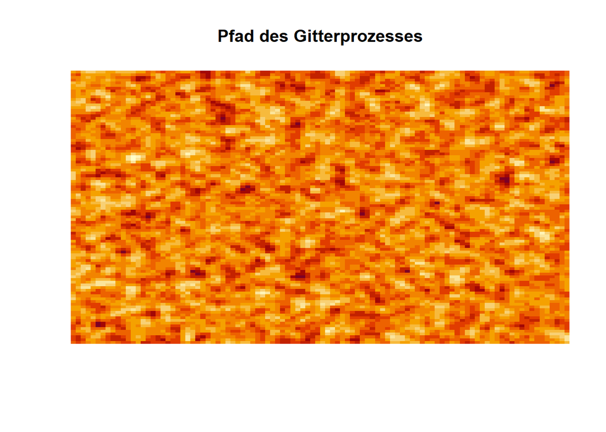

```r
gridProcess <- function(N, M, mu, sigma, padding = nrow(sigma) %/% 2) {
  N_tilde <- N + 2 * padding
  M_tilde <- M + 2 * padding
  n <- N_tilde * M_tilde

  eps <- matrix(rnorm(n,
                      # normalize the mean such that E(X_ij) = mu
                      mu / sum(sigma),
                      # for variance take the middle of the matrix sigma
                      sigma[nrow(sigma) %/% 2 + 1, ncol(sigma) %/% 2 + 1]),
                nrow = M_tilde,
                ncol = N_tilde)

  x <- convolve_image(eps, sigma)
  # cut padding
  return(x[(padding+1):(M+padding),(padding+1):(N+padding)])
}

sigma <- matrix(.5, nrow = 3, ncol = 3)
sigma[2,2] <- 1

image(gridProcess(100, 100, 1, sigma), axes = F, main = "Pfad des Gitterprozesses")
```

## Periodogramm

```r
I <- function(x){
  # use twodim fft

}
```

```r
f_hat <- function(periodogram, kernel) {
  # use convolve_image on I
  # should be function factory

}

f_hat_randomized <- function(I_x, I_y, kernel) {
  # use convolve_image on I_x and I_y with random permutations
  # randomized inner product and then apply f_hat

}
```

## $T_n$

```r
Tn <- function(x) {
  # use integrate
}
```

# Literatur

Jentsch, Carsten, and Markus Pauly. 2015. “Testing Equality of Spectral Densities Using Randomization Techniques.”